# corr_matrix

Jordan Lee

12/1/2020

# run step1_clean.ipynb first

# Correlation Matrix

https://uc-r.github.io/hc_clustering

https://stats.stackexchange.com/questions/2976/clustering-variables-based-on-correlations-between-them

```r
########## hardcoded
ftsets <- '../data/exact_match/best_models_BRCA.tsv'
upsetmode <- 'distinct'
init_vector <- c(clust1 = 0, clust2 = 0, clust3 = 0, clust4 = 0, clust5 = 0, clust6 = 0, clust7=0, clust8=0) # where len == n_clusters
team_order_upset <- c('JADBIO', 'CloudForest', 'AKLIMATE', 'SUBSCOPE', 'SciKitGrid')

file = '../data/heatmap/BRCA_vals_cnvr.tsv'
cancer = 'BRCA'
datatype <- 'I:CNVR::'

##########
```

### Data Prep

Read in file containing Theo’s raw tarball values for features selected by teams (one best model per team). Reformat. Data format row:col:val is sample:feature:tarball_value

**TODO**

- rownames(df) line assumes the first col is the sample col

### Clustering features based on signal

Cluster features based on signal (from raw tarball).

1. Identify the strongest clustering structure of several methods `"average", "single", "complete", "ward"` for our data
2. Apply best clustering method in agglomerative clustering (AGNES) `agnes()`

Why AGNES instead of DIANA?

- Agglomerative clustering (AGNES). Won’t be using divisice hierarchial clustering (DIANA)
- Use `agnes()` instead of `hclust`

Agglomerative coefficient

- Measure of the clustering structure. “measure dissimilarity of object to the first cluster it joins, divided by the dissimilarity of the final merger in the cluster analysis, averaged across samples”. larger == larger strength of clustering
- AC tends to increase with sample size
- Can be compared to the silhouette coefficient

```
##      ward  complete   average    single
## 0.5511775 0.4626267 0.3111892 0.2283887
```

```
## [1] "method with largest agglomerative coefficient:"
```

```
## [1] "ward"
```

```r
library(factoextra)
```

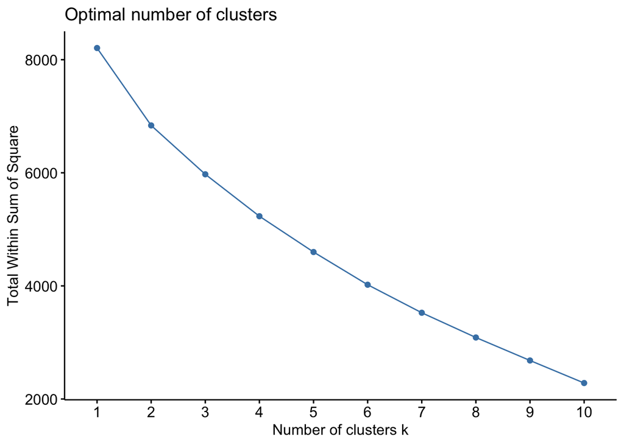

```r
library(NbClust)

######
# hcut
######
# Find optimal n clusters
# 1. WSS
res_wss <-fviz_nbclust(df, FUNcluster = hcut, method = "wss", k.max = 10, print.summary = TRUE)
# print(res_wss$labels)
res_wss
```

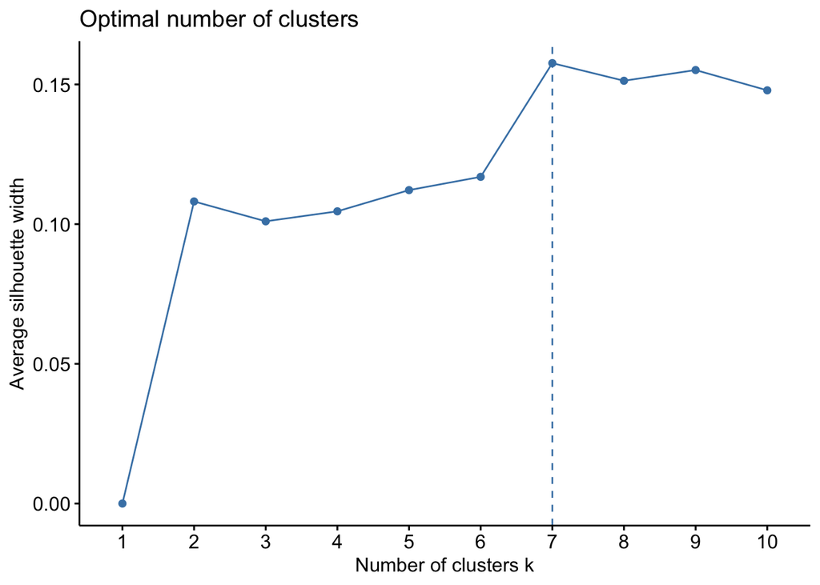

```r
# 2. Silhouette
res_sill <-fviz_nbclust(df, FUNcluster = hcut, method = "silhouette", k.max = 10, print.summary = TRUE)
res_sill
```

```r
# expand to print the opti number
data <- res_sill$data[order(res_sill$data$y, decreasing = TRUE),]
n_clusters <- data[1,1]
print('optimal number of clusters')
```

```
## [1] "optimal number of clusters"
```

```r
print(n_clusters)
```

```
## [1] 7
## Levels: 1 2 3 4 5 6 7 8 9 10
```

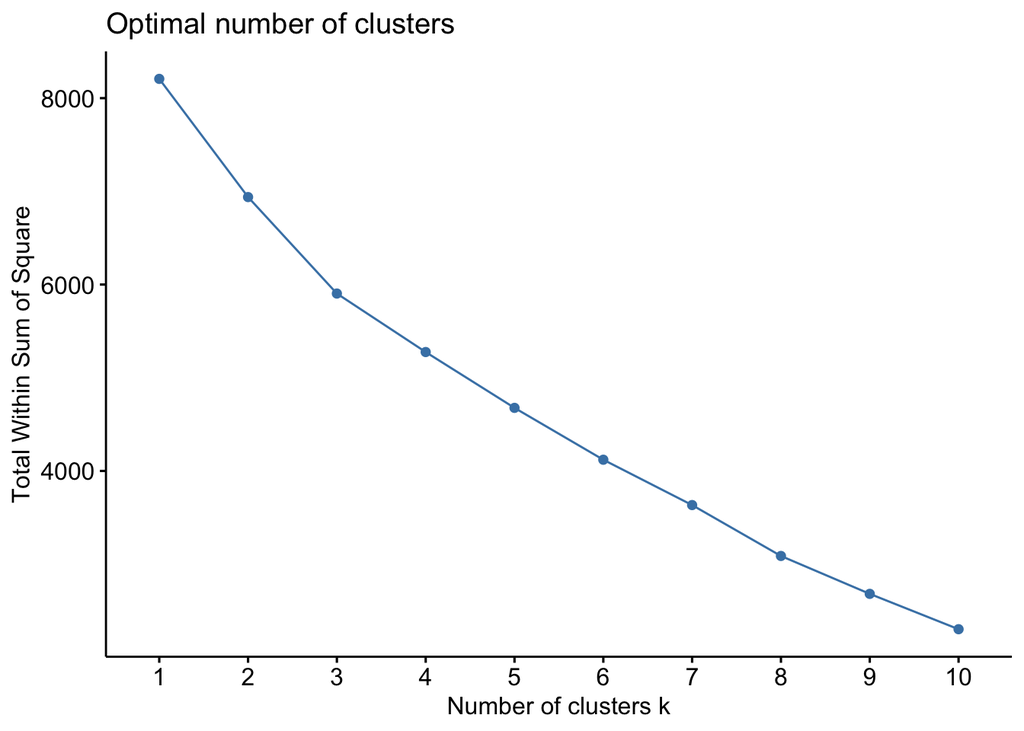

```r
# add one
n_clusters <- n_clusters %>% as.integer() +1

#######
#B. Kmeans**
#######
# 1. kmeans clustering
fviz_nbclust(df, kmeans, method = "wss", print.summary = TRUE)
```

### Dendrogram

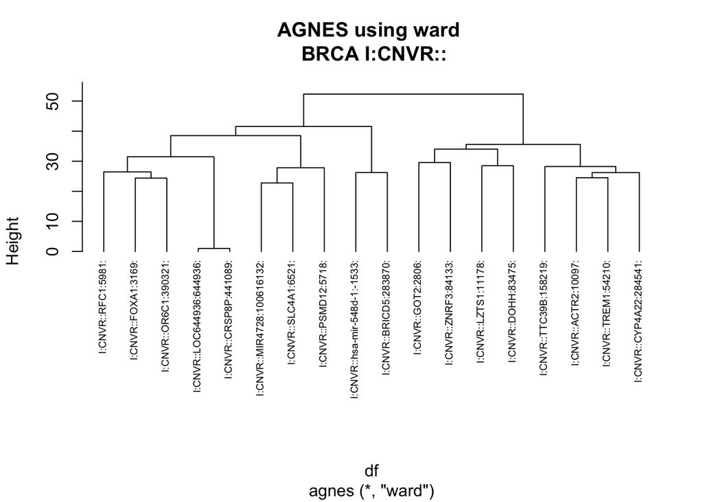

```r
# Plot
hc <- agnes(df, method = best_method)
pltree(hc, cex = 0.6, hang = -50, main = paste("AGNES using",best_method,'\n', cancer, datatype))
```

How many features in each cluster?

| clusterID | n_members |
| --- | --- |
| 1 | 3 |
| 2 | 1 |
| 3 | 2 |
| 4 | 4 |
| 5 | 3 |
| 6 | 2 |
| 7 | 2 |
| 8 | 1 |

Specifically which features? (head of data)

```
##    clusterID                           fts
## 14         5          I:CNVR::PSMD12:5718:
## 10         6 I:CNVR::hsa-mir-548d-1:-1533:
## 17         6        I:CNVR::BRICD5:283870:
## 13         7          I:CNVR::LZTS1:11178:
## 16         7           I:CNVR::DOHH:83475:
## 18         8          I:CNVR::ZNRF3:84133:
```

### Now examine in context of teams

Read in best model from each team. Which teams?

```
## [1] "gnosis_1_BRCA"
## [1] "found 0 ft"
## [1] "CF|All_Top 100_BRCA"
## [1] "found 0 ft"
## [1] "AKLIMATE_BRCA_reduced_model_1000_feature_set_BRCA"
## [1] "found >= 1 ft"
## [1] "nn_jg_2020-03-20_top1kfreq:BRCA_BRCA"
## [1] "found 0 ft"
## [1] "fbedeBIC_BRCA"
## [1] "found >= 1 ft"
```

Binary membership table

|  | gnosis_1_BRCA | CF\|All_Top 100_BRCA | AKLIMATE_BRCA_reduced_model_1000_feature_set_BRCA | nn_jg_2020-03-20_top1kfreq:BRCA_BRCA | fbedeBIC_BRCA |
| --- | --- | --- | --- | --- | --- |
| clust1 | 0 | 0 | 0 | 0 | 1 |
| clust2 | 0 | 0 | 0 | 0 | 1 |
| clust3 | 0 | 0 | 1 | 0 | 1 |
| clust4 | 0 | 0 | 0 | 0 | 1 |
| clust5 | 0 | 0 | 0 | 0 | 1 |
| clust6 | 0 | 0 | 0 | 0 | 1 |
| clust7 | 0 | 0 | 0 | 0 | 1 |
| clust8 | 0 | 0 | 0 | 0 | 1 |

### Upset plot

Overlap of clusters

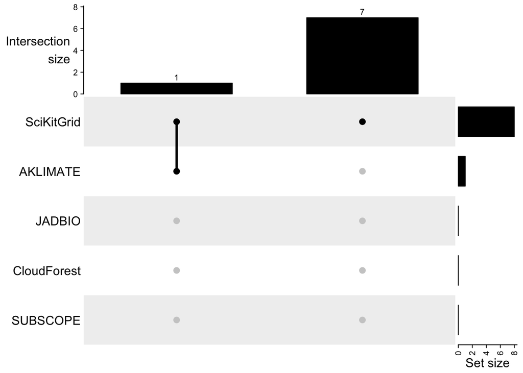